# Effects of borrower characteristics on loan interest rate.

## by Deepti Khona

## Investigation Overview

In this investigation, I wanted to see which borrower characteristics and factors affect the interest rate

## Dataset Overview

The data has 113937 listings and 80 columns of variables in columns. Factors that were evaluated were CreditScore(lower range), Employment status, reason for loan(Listing Category). We dropped data with creditscore that was 0, and also for borrowers rate, we dropped outliers less than 0.04 and above 0.36.

## Distribution of Borrower Rate

> The borrowers rate shows that maximum number of borrowers received a rate of 0.14-0.16.

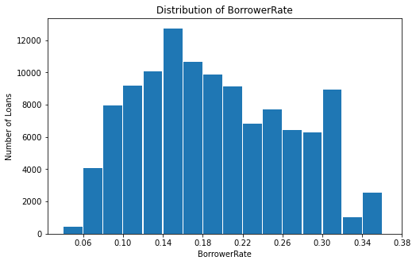

## Distribution of Employment Status

> This plot shows that Employed people have the largest loans, followed by full-time and self-employed. However Part-time, not employed, and retired have the lowest number of loans

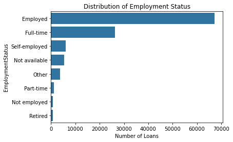

## Distribution of CreditScoreRangeLower vs. BorrowerRate

> The scatter plot of CreditScoreRangeLower vs. BorrowerRate, with log transform shows a negative relationship between the variables. This is because the borrowers with higher/better creditscore received lower interest rate.

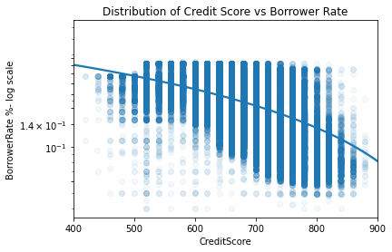

# Distribution of Employment Status and Type of Loan(Listing Category) vs. BorrowerRate

> The multivariate plot above shows that the full-time borrowers with Green loans and Motorcyle have the lowest rate, vs the un-employed with wedding loans and green loans and full time borrowers with engagement ring loans had the highest rate. Overall the fulltime and employed see to have the lower interest rates compared to the un-employed, regardless of the the listing category.

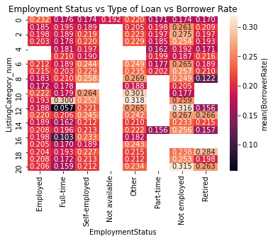